# 11 Concordancing

Author

Affiliation

Vladimir Buskin

Catholic University of Eichstätt-Ingolstadt

## 11.1 Suggested reading

In-depth introduction to concordancing with R:

> Schweinberger (2024)

Naturale Language Processing (NLP) with `quanteda`:

> Benoit et al. (2018)

> [Online reference](http://quanteda.io)

On corpus-linguistic theory:

> Wulff and Baker (2020)

> Lange and Leuckert (2020)

> McEnery, Xiao, and Yukio (2006)

## 11.2 Preparation

**Script**

You can find the full R script associated with this unit [here](https://osf.io/duras).

**Working directory**

In order for R to be able to recognise the data, it is crucial to set up the working directory correctly.

1. Make sure your R-script **and** the corpus (e.g., ‘ICE-GB’) are stored in the **same folder** on your computer.
2. In RStudio, go to the `Files` pane (usually in the bottom-right corner) and navigate to the location of your script. Alternatively, you can click on the three dots `...` and use the file browser instead.
3. Once you’re in the correct folder, click on the blue ⚙️ icon.
4. Select `Set As Working Directory`. This action will update your working directory to the folder where the file is located.

In addition, make sure you have installed `quanteda`. Load it at the beginning of your script:

```r
library(quanteda) # Package for Natural Language Processing in R
library(lattice) # for dotplots
```

To load a corpus object into R, place it in your working directory and read it into your working environment with `readRDS()`.[^1]

<sup>1</sup> The `ICE-GB.RDS` file you’ve been provided with has been pre-processed and saved in this specific format for practical reasons.

```r
# Load corpus from directory
ICE_GB <- readRDS("ICE_GB.RDS")
```

If you encounter any error messages at this stage, ensure you followed steps 1 and 2 in the callout box above.

## 11.3 Concordancing

A core task in corpus-linguistic research involves finding occurrences of a single word or multi-word sequence in the corpus. Lange & Leuckert (2020: 55) explain that specialised software typically “provide[s] the surrounding context as well as the name of the file in which the word could be identified.” Inspecting the context is particularly important in comparative research, as it may be indicative of distinct usage patterns.

### 11.3.1 Simple queries

To obtain such a **keyword in context (KWIC)** in R**,** we use the `kwic()` function. We supply the corpus as well as the keyword we’re interested in:

```r
query1 <- kwic(ICE_GB, "eat")
```

The output in `query1` contains **concordance lines** that list all occurrences of the keyword, including the document, context to the left, the keyword itself, and the context to the right. The final column reiterates our search expression.

```r
head(query1)
```

```
Keyword-in-context with 6 matches.
  [ICE_GB/S1A-006.txt, 785]           So I' d rather | eat |
 [ICE_GB/S1A-009.txt, 1198]              I must <, > | eat |
  [ICE_GB/S1A-010.txt, 958]         to <, > actually | eat |
  [ICE_GB/S1A-018.txt, 455] order one first and then | eat |
  [ICE_GB/S1A-018.txt, 498]  A > The bargain hunting | eat |
 [ICE_GB/S1A-023.txt, 1853]       B > Oh name please | eat |

 beforehand just to avoid uh
 them < ICE-GB:S1A-009#71:
 it for one' s
 it and then sort of
 < ICE-GB:S1A-018#29: 1
 something <,, >
```

For a full screen display of the KWIC data frame, try `View()`:

```r
View(query1)
```

| docname | from | to | pre | keyword | post | pattern |
| --- | --- | --- | --- | --- | --- | --- |
| ICE_GB/S1A-006.txt | 785 | 785 | So I ' d rather | eat | beforehand just to avoid uh | eat |
| ICE_GB/S1A-009.txt | 1198 | 1198 | I must < , > | eat | them < ICE-GB:S1A-009 #71 : | eat |
| ICE_GB/S1A-010.txt | 958 | 958 | to < , > actually | eat | it for one ' s | eat |
| ICE_GB/S1A-018.txt | 455 | 455 | order one first and then | eat | it and then sort of | eat |
| ICE_GB/S1A-018.txt | 498 | 498 | A > The bargain hunting | eat | < ICE-GB:S1A-018 #29 : 1 | eat |
| ICE_GB/S1A-023.txt | 1853 | 1853 | B > Oh name please | eat | something < , , > | eat |

### 11.3.2 Multi-word queries

If the search expression exceeds a single word, we need to mark it as a multi-word sequence by means of the `phrase()` function. For instance, if we were interested in the pattern *eat a*, we’d have to adjust the code as follows:

```r
query2 <- kwic(ICE_GB, phrase("eat a"))
```

```r
View(query2)
```

| docname | from | to | pre | keyword | post | pattern |
| --- | --- | --- | --- | --- | --- | --- |
| ICE_GB/S1A-059.txt | 2230 | 2231 | 1 : B > I | eat a | < , > very balanced | eat a |
| ICE_GB/W2B-014.txt | 1045 | 1046 | : 1 > We can't | eat a | lot of Welsh or Scottish | eat a |
| ICE_GB/W2B-022.txt | 589 | 590 | have few labour-saving devices , | eat a | diet low in protein , | eat a |

### 11.3.3 Multiple simultaneous queries

A very powerful advantage of `quanteda` over traditional corpus software is that we can query a corpus for a multitude of keywords **at the same time**. Say, we need our output to contain hits for *eat*, *drink* as well as *sleep*. Instead of a single keyword, we supply a character vector containing the strings of interest.

```r
query3 <- kwic(ICE_GB, c("eat", "drink", "sleep"))
```

```r
View(query3)
```

| docname | from | to | pre | keyword | post | pattern |
| --- | --- | --- | --- | --- | --- | --- |
| ICE_GB/S1A-006.txt | 785 | 785 | So I ' d rather | eat | beforehand just to avoid uh | eat |
| ICE_GB/S1A-009.txt | 869 | 869 | : A > Do you | drink | quite a lot of it | drink |
| ICE_GB/S1A-009.txt | 1198 | 1198 | I must < , > | eat | them < ICE-GB:S1A-009 #71 : | eat |
| ICE_GB/S1A-010.txt | 958 | 958 | to < , > actually | eat | it for one ' s | eat |
| ICE_GB/S1A-014.txt | 3262 | 3262 | you were advised not to | drink | water in Leningrad because they | drink |
| ICE_GB/S1A-016.txt | 3290 | 3290 | > I couldn't I couldn't | sleep | if I didn't read < | sleep |

### 11.3.4 Window size

Some studies require more detailed examination of the preceding or following context of the keyword. We can easily adjust the `window` size to suit our needs:

```r
query4 <- kwic(ICE_GB, "eat", window = 20)
```

| docname | from | to | pre | keyword | post | pattern |
| --- | --- | --- | --- | --- | --- | --- |
| ICE_GB/S1A-006.txt | 785 | 785 | #49 : 1 : A > Yeah < ICE-GB:S1A-006 #50 : 1 : A > So I ' d rather | eat | beforehand just to avoid uh < , , > any problems there < ICE-GB:S1A-006 #51 : 1 : B > | eat |
| ICE_GB/S1A-009.txt | 1198 | 1198 | < , > in in the summer < ICE-GB:S1A-009 #70 : 1 : A > I must < , > | eat | them < ICE-GB:S1A-009 #71 : 1 : A > Yes < ICE-GB:S1A-009 #72 : 1 : B > You ought | eat |
| ICE_GB/S1A-010.txt | 958 | 958 | 1 : B > You know I mean it would seem to be squandering it to < , > actually | eat | it for one ' s own enjoyment < , , > < ICE-GB:S1A-010 #49 : 1 : A > Mm | eat |
| ICE_GB/S1A-018.txt | 455 | 455 | s so < ICE-GB:S1A-018 #27 : 1 : A > What you should do is order one first and then | eat | it and then sort of carry on from there < laughter > < , > by which time you wouldn't | eat |
| ICE_GB/S1A-018.txt | 498 | 498 | second anyway so < laugh > < , > < ICE-GB:S1A-018 #28 : 1 : A > The bargain hunting | eat | < ICE-GB:S1A-018 #29 : 1 : B > So all right what did I have < ICE-GB:S1A-018 #30 : 1 | eat |
| ICE_GB/S1A-023.txt | 1853 | 1853 | > I can't bear it < , , > < ICE-GB:S1A-023 #121 : 1 : B > Oh name please | eat | something < , , > < ICE-GB:S1A-023 #122 : 1 : A > Oh actually Dad asked me if < | eat |

### 11.3.5 Saving your output

You can store your results in a spreadsheet file just as described in the unit on importing and exporting data.

- **Microsoft Excel (**.xlsx**)**

```r
library(writexl) # required for writing files to MS Excel

write_xlsx(query1, "myresults1.xlsx")
```

- **LibreOffice** (.csv)

```r
write.csv(query1, "myresults1.csv")
```

As soon as you have annotated your data, you can load .xlsx files back into R with `read_xlsx()` from the `readxl` package and .csv files using the Base R function `read.csv()`.

## 11.4 Characterising the output

Recall our initial query of the *eat*, whose output we stored in `query1`:

| docname | from | to | pre | keyword | post | pattern |
| --- | --- | --- | --- | --- | --- | --- |
| ICE_GB/S1A-006.txt | 785 | 785 | So I ' d rather | eat | beforehand just to avoid uh | eat |
| ICE_GB/S1A-009.txt | 1198 | 1198 | I must < , > | eat | them < ICE-GB:S1A-009 #71 : | eat |
| ICE_GB/S1A-010.txt | 958 | 958 | to < , > actually | eat | it for one ' s | eat |
| ICE_GB/S1A-018.txt | 455 | 455 | order one first and then | eat | it and then sort of | eat |
| ICE_GB/S1A-018.txt | 498 | 498 | A > The bargain hunting | eat | < ICE-GB:S1A-018 #29 : 1 | eat |
| ICE_GB/S1A-023.txt | 1853 | 1853 | B > Oh name please | eat | something < , , > | eat |

First, we may be interested in obtaining some general information on our results, such as …

- … how many **tokens** (= individual hits) does the query return?

The `nrow()` function counts the number of rows in a data frame — these always correspond to the number of **observations** in our sample (here: 53).

```r
nrow(query1)
```

```
[1] 53
```

- … how many **types** (= distinct hits) does the query return?

Apparently, there are 52 counts of *eat* in lower case and 1 in upper case. Their sum corresponds to our 53 observations in total.

```r
table(query1$keyword)
```

```
eat Eat
 52   1
```

- … how is the keyword distributed across corpus files?

This question relates to the notion of **dispersion**: Is a keyword spread relatively evenly across corpus files or does it only occur in specific ones?

```r
# Frequency of keyword by docname
query_distrib <- table(query1$docname, query1$keyword)

# Show first few rows
head(query_distrib)
```

```
                     eat Eat
  ICE_GB/S1A-006.txt   1   0
  ICE_GB/S1A-009.txt   1   0
  ICE_GB/S1A-010.txt   1   0
  ICE_GB/S1A-018.txt   2   0
  ICE_GB/S1A-023.txt   1   0
  ICE_GB/S1A-025.txt   1   0
```

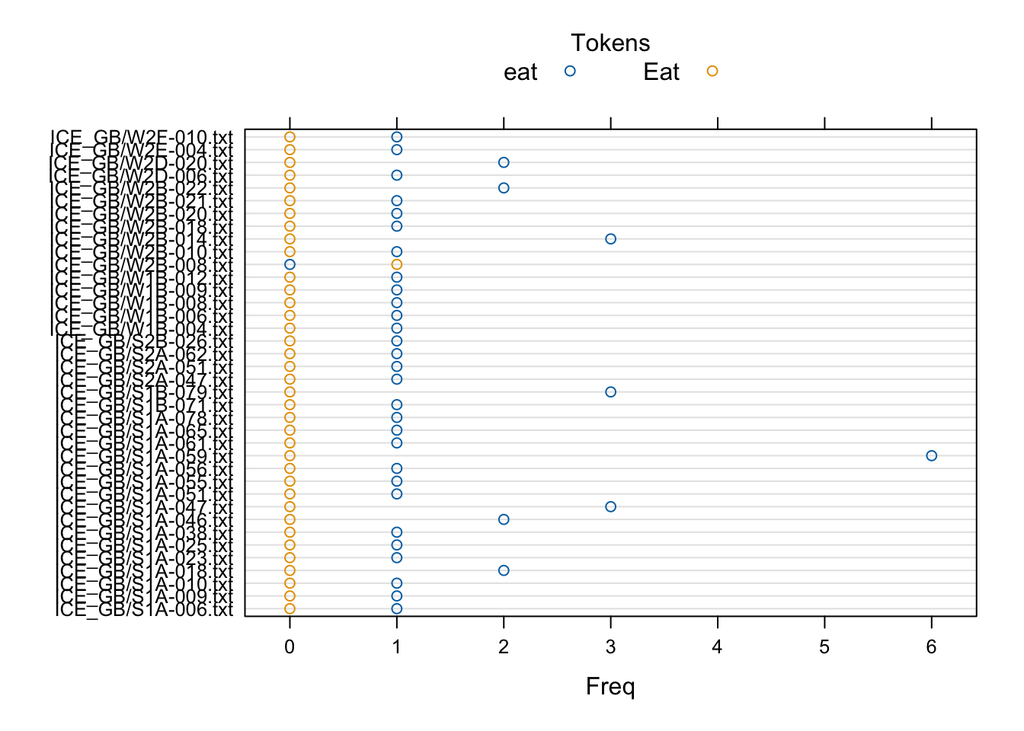

```r
# Create a simple dot plot
dotplot(query_distrib, auto.key = list(columns = 2, title = "Tokens", cex.title = 1))
```

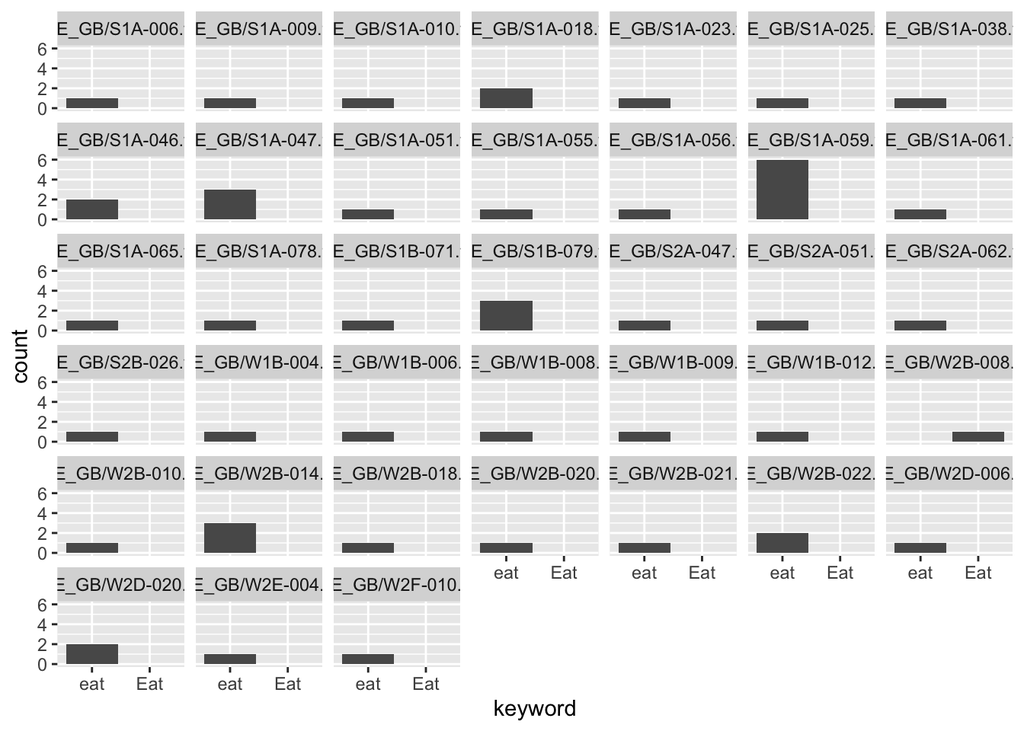

```r
# Create a fancy plot (requires tidyverse)
ggplot(query1, aes(x = keyword)) +
  geom_bar() +
  facet_wrap(~docname)
```

It seems that *eat* occurs at least once in most text categories (both spoken and written), but seems to be much more common in face-to-face conversations (S1A). This is not surprising: It is certainly more common to discuss food in a casual chat with friends than in an academic essay (unless, of course, its main subject matter is food). Dispersion measures can thus be viewed as indicators of **contextual preferences** associated with lexemes or more grammatical patterns.

**Advanced: More on dispersion**

The empirical study of dispersion has attracted a lot of attention in recent years Gries (2020). A reason for this is the necessity of finding a dispersion measure that is minimally correlated with token frequency. One such measure is the Kullback-Leibler divergence $KLD$, which comes from the field of information theory and is closely related to entropy.

Mathematically, $KLD$ measures the difference between two probability distributions $p$ and $q$.

$$KLD(p \parallel q) = \sum\limits_{x \in X} p(x) \log \frac{p(x)}{q(x)}
\tag{11.1}$$

Let $f$ denote the overall frequency of a keyword in the corpus, $v$ its frequency in each corpus part, $s$ the sizes of each corpus part (as fractions) and $n$ the total number of corpus parts. We thus compare the posterior (= “actual”) distribution of keywords $\frac{v_i}{f}$ for $i = 1, ..., n$ with their prior distribution, which assumes all words are spread evenly across corpus parts (hence the division by $s_i$).

$$KLD = \sum\limits_{i=1}^n \frac{v_i}{f} \times \log_2\left({\frac{v_i}{f} \times \frac{1}{s_i}}\right)
\tag{11.2}$$

In R, let’s calculate the dispersion of the verbs *eat*, *drink*, and *sleep* from `query3`.

```r
# Let's filter out the upper-case variants:
query3_reduced <- query3[query3$keyword %in% c("eat", "drink", "sleep"),]
table(query3_reduced$keyword)
```

```
drink   eat sleep
   48    52    41
```

```r
# Extract text categories
query_registers <- separate_wider_delim(query3_reduced, cols = docname, delim = "-", names = c("Text_category", "File_number"))

# Get separate data frames for each verb
eat <- filter(query_registers, keyword == "eat")
drink <- filter(query_registers, keyword == "drink")
sleep <- filter(query_registers, keyword == "sleep")

## Get frequency distribution across files
v_eat <- table(eat$Text_category)
v_drink <- table(drink$Text_category)
v_sleep <- table(sleep$Text_category)

## Get total frequencies
f_eat <- nrow(eat)
f_drink <- nrow(drink)
f_sleep <- nrow(sleep)

# The next step is a little trickier. First we need to find out how many distinct corpus parts there are in the ICE corpus.

## Check ICE-corpus structure and convert to data frame
ICE_GB_str <- as.data.frame(summary(ICE_GB))

## Separate files from text categores
ICE_GB_texts <- separate_wider_delim(ICE_GB_str, cols = Var1, delim = "-", names = c("Text_category", "File"))

## Get number of distinct text categories
n <- length(unique(ICE_GB_texts$Text_category))

## Get proportions of distinct text categories (s)
s <- table(ICE_GB_texts$Text_category)/sum(table(ICE_GB_texts$Text_category))

## Unfortunately not all of these corpus parts are represented in our queries. We need to correct the proportions in s for the missing ones!

## Store unique ICE text categories
ICE_unique_texts <- unique(ICE_GB_texts$Text_category)

## Make sure only those text proportions are included where the keywords actually occur
s_eat <- s[match(names(v_eat), ICE_unique_texts)]
s_drink <- s[match(names(v_drink), ICE_unique_texts)]
s_sleep <- s[match(names(v_sleep), ICE_unique_texts)]

# Compute KLD for each verb
kld_eat <- sum(v_eat/f_eat * log2(v_eat/f_eat * 1/s_eat)); kld_eat
```

```
[1] 0.6747268
```

```r
kld_drink <- sum(v_drink/f_drink * log2(v_drink/f_drink * 1/s_drink)); kld_drink
```

```
[1] 0.8463608
```

```r
kld_sleep <- sum(v_sleep/f_sleep * log2(v_sleep/f_sleep * 1/s_sleep)); kld_sleep
```

```
[1] 0.7047421
```

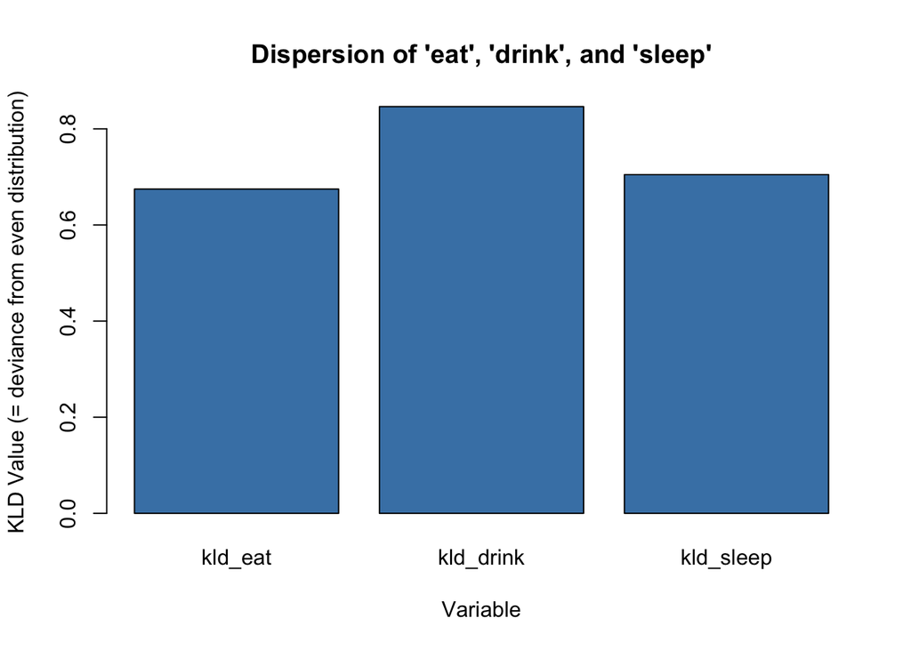

```r
# Plot
kld_df <- data.frame(kld_eat, kld_drink, kld_sleep)

barplot(as.numeric(kld_df), names.arg = names(kld_df), col = "steelblue",
        xlab = "Variable", ylab = "KLD Value (= deviance from even distribution)", main = "Dispersion of 'eat', 'drink', and 'sleep'")
```

The plot indicates that *drink* is the most unevenly distributed verb out of the three considered (high KDL $\sim$ low dispersion), whereas *eat* appears to be slightly more evenly distributed across corpus files. The verb *sleep* assumes an intermediary position.

## 11.5 “I need a proper user interface”: Some alternatives

There is a wide variety of concordancing software available, both free and paid. Among the most popular options are AntConc (Anthony 2020) and SketchEngine (Kilgarriff et al. 2004). However, as Schweinberger (2024) notes, the exact processes these tools use to generate output are not always fully transparent, making them something of a “black box.” In contrast, programming languages like R or Python allow researchers to document each step of their analysis clearly, providing full transparency from start to finish.

The following apps attempt to reconcile the need for an intuitive user interface with transparent data handling. The full source code is documented in the respective GitHub repositories.

- [`QuantedaApp`](https://github.com/VBuskin/quanteda_app) is an interface for the R package `quanteda` (Benoit et al. 2018).
- [`PyConc`](https://github.com/VBuskin/PyConc) is an interface for the Python package `spaCy` (Honnibal and Montani 2017).

Anthony, Lawrence. 2020. *AntConc (Version 3.5.9)*. Tokyo, Japan: Waseda University. https://www.laurenceanthony.net/software.

Benoit, Kenneth, Kohei Watanabe, Haiyan Wang, Paul Nulty, Adam Obeng, Stefan Müller, and Akitaka Matsuo. 2018. “Quanteda: An r Package for the Quantitative Analysis of Textual Data.” *Journal of Open Source Software* 3 (30): 774. https://doi.org/10.21105/joss.00774.

Gries, Stefan Thomas. 2020. “Analyzing Dispersion.” In *A Practical Handbook of Corpus Linguistics*, edited by Magali Paquot and Stefan Thomas Gries, 99–118. Cham: Springer.

Honnibal, Matthew, and Ines Montani. 2017. “spaCy 2: Natural Language Understanding with Bloom Embeddings, Convolutional Neural Networks and Incremental Parsing.”

Kilgarriff, Adam, Pavel Rychly, Pavel Smrz, and David Tugwell. 2004. “ITRI-04-08 the Sketch Engine.” *Information Technology* 105: 116.

Lange, Claudia, and Sven Leuckert. 2020. *Corpus Linguistics for World Englishes: A Guide for Research*. New York: Taylor; Francis.

McEnery, Tony, Richard Xiao, and Tono Yukio. 2006. *Corpus-Based Language Studies: An Advanced Resource Book*. London: Routledge.

Schweinberger, Martin. 2024. *Concordancing with r*. 2024.05.07 ed. Brisbane: The Language Technology; Data Analysis Laboratory (LADAL). https://ladal.edu.au/kwics.html.

Sönning, Lukas. 2024. “Evaluation of Keyness Metrics: Performance and Reliability,” Corpus Linguistics and Linguistic Theory, 20 (2): 263–88. https://doi.org/10.1515/cllt-2022-0116.

Wulff, Stefanie, and Paul Baker. 2020. “Analyzing Concordances.” In *A Practical Handbook of Corpus Linguistics*, edited by Magali Paquot and Stefan Th. Gries, 161–79. Cham: Springer International Publishing. https://doi.org/10.1007/978-3-030-46216-1_8.